# Time Series

HJ. S.

2023-11-30

时间序列分析是一种统计技术，它涉及按时间顺序观察和分析数据点，以识别数据中的模式、趋势和周期性，以及进行预测。这是金融、经济学、商业、科学和工程等许多领域中的一个重要部分。

# 时间序列分析的关键组成部分

1. **趋势（Trend）**:
   - 长期趋势，可能是上升或下降，反映了数据的总体方向。
2. **季节性（Seasonality）**:
   - 周期性的波动，通常与特定季节或时间段有关。
3. **循环（Cyclic）**:
   - 数据显示的长期波动，不一定与固定季节性模式相关。
4. **随机成分（Random Component）**:
   - 无法被模型预测的不规则或随机波动。

# 时间序列分析的方法

1. **移动平均（Moving Average）**:
   - 用于平滑时间序列数据，以观察长期趋势。
2. **自回归模型（AR）**:
   - 模型假设当前值与历史值相关。
3. **移动平均模型（MA）**:
   - 模型关注序列中的误差项及其对当前值的影响。
4. **自回归移动平均模型（ARMA）**:
   - 结合了自回归和移动平均模型的特点。
5. **自回归积分滑动平均模型（ARIMA）**:
   - 适用于非平稳数据，通过差分将数据转换为平稳序列。
6. **季节性自回归积分滑动平均模型（SARIMA）**:
   - ARIMA的扩展，用于具有季节性模式的数据。

## 注意事项

- 在应用这些模型之前，重要的是先对数据进行适当的检查和预处理，包括检查数据的平稳性、季节性以及是否存在异常值。
- 模型的选择应基于数据的特性，例如是否平稳、是否有季节性等。
- 模型的验证和诊断也是分析过程的重要部分，以确保模型的准确性和适用性。

# 时间序列分析的R语言实现

在R中，`forecast`包提供了强大的时间序列分析和预测功能。以下是使用`forecast`包进行时间序列分析的一个基本示例：

```r
# 安装和加载forecast包
if (!require("forecast")) install.packages("forecast")
```

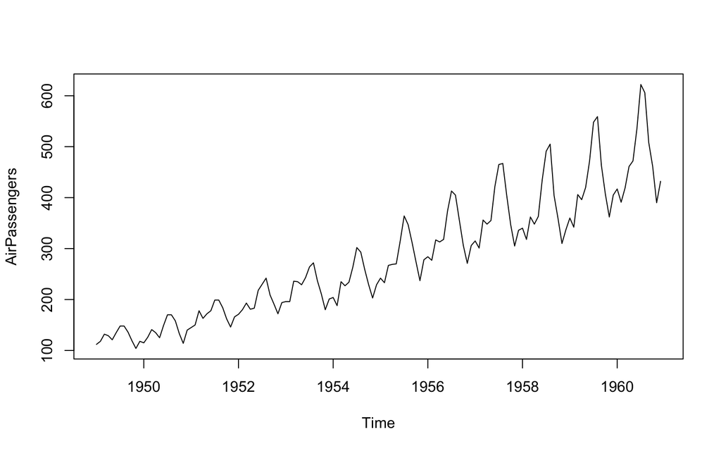

```r
library(forecast)

# 创建一个时间序列数据，这里我们使用AirPassengers数据集
data("AirPassengers")

# 查看数据的基本时间序列图
plot(AirPassengers)
```

```r
# 使用自动ARIMA模型对数据进行建模
fit <- auto.arima(AirPassengers)

# 摘要模型结果
summary(fit)
```

```
## Series: AirPassengers
## ARIMA(2,1,1)(0,1,0)[12]
##
## Coefficients:
##          ar1     ar2      ma1
##       0.5960  0.2143  -0.9819
## s.e.  0.0888  0.0880   0.0292
##
## sigma^2 = 132.3:  log likelihood = -504.92
## AIC=1017.85   AICc=1018.17   BIC=1029.35
##
## Training set error measures:
##                    ME     RMSE      MAE       MPE     MAPE     MASE
## Training set 1.342306 10.84619 7.867539 0.4206996 2.800458 0.245628
##                      ACF1
## Training set -0.001248451
```

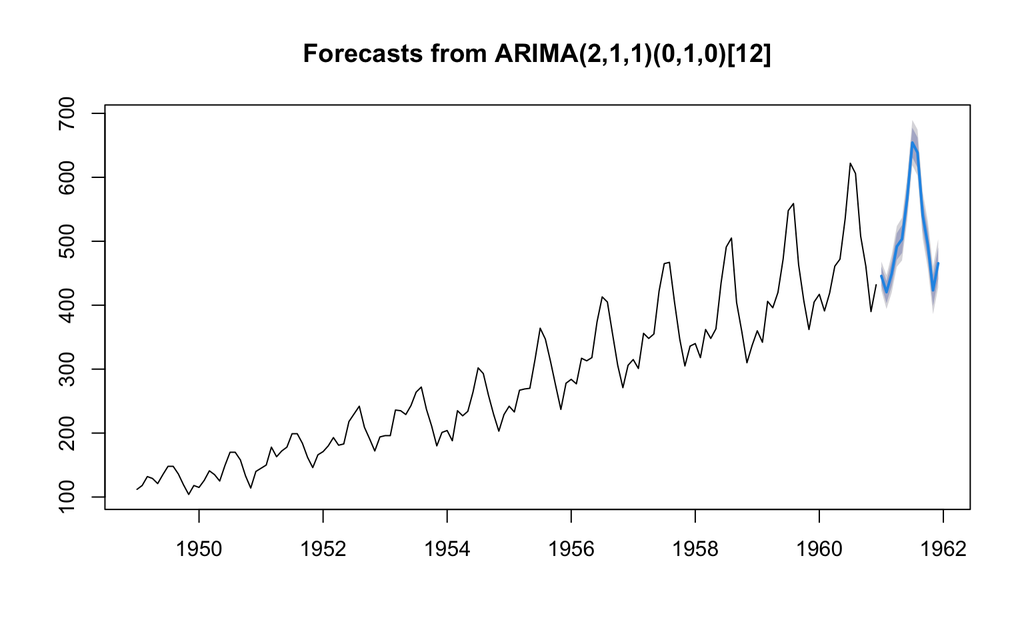

```r
# 预测未来12个时间点的数据
forecast <- forecast(fit, h = 12)

# 绘制预测结果
plot(forecast)
```

## 1. 移动平均（Moving Average, MA）

移动平均是时间序列分析中用于平滑数据的一种基本技术。它通过计算数据点的连续子集的平均值来创建一系列平均值。

- **应用**:
  - 识别数据的趋势。
  - 去除短期波动，更清晰地看到长期趋势。

Moving Average, 移动平均是一种用于平滑时间序列数据的方法，它有助于我们识别趋势并去除短期波动。

使用R语言分析苹果（Apple）、微软（Microsoft）和谷歌（Google）的股票数据。我们可以使用quantmod包从公开的金融数据源获取这些数据，并计算移动平均。

**第一步：安装和加载必要的包**

```r
if (!require("quantmod")) install.packages("quantmod")
library(quantmod)
```

**第二步：获取股票数据**

```r
# 获取苹果、微软和谷歌的股票数据
getSymbols("AAPL", src = "yahoo", from = "2020-01-01", to = "2023-01-01")
```

```
## [1] "AAPL"
```

```r
getSymbols("MSFT", src = "yahoo", from = "2020-01-01", to = "2023-01-01")
```

```
## [1] "MSFT"
```

```r
getSymbols("GOOG", src = "yahoo", from = "2020-01-01", to = "2023-01-01")
```

```
## [1] "GOOG"
```

**第三步：计算移动平均**

```r
# 对每个股票计算30天移动平均
AAPL$SMA30 <- SMA(Cl(AAPL), 30)
MSFT$SMA30 <- SMA(Cl(MSFT), 30)
GOOG$SMA30 <- SMA(Cl(GOOG), 30)
```

**第四步：绘制价格和移动平均**

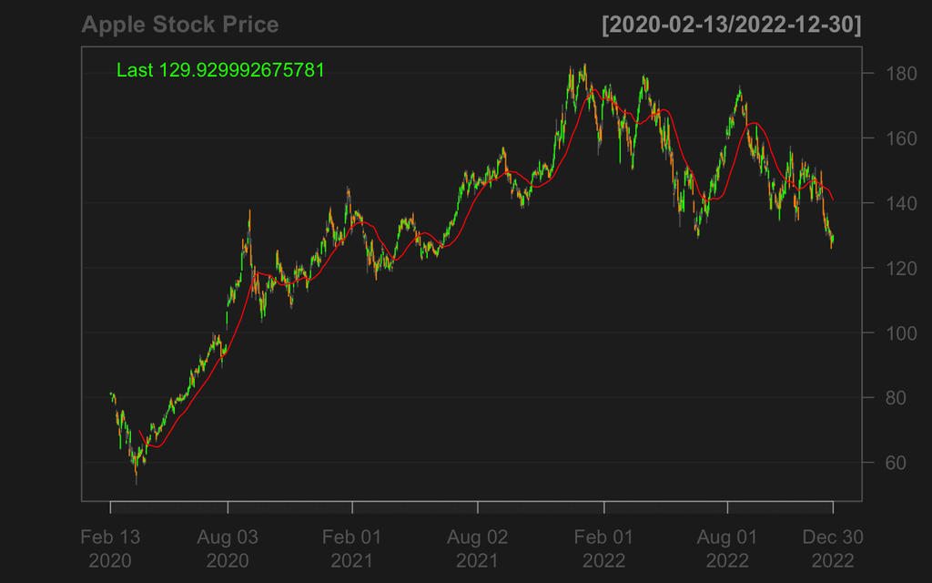

```r
# 绘制苹果的股价和30天移动平均
chartSeries(AAPL, name = "Apple Stock Price", TA = "addSMA(n = 30, col = 'red')")
```

重复上述步骤为微软和谷歌的股票绘制相应的图表。

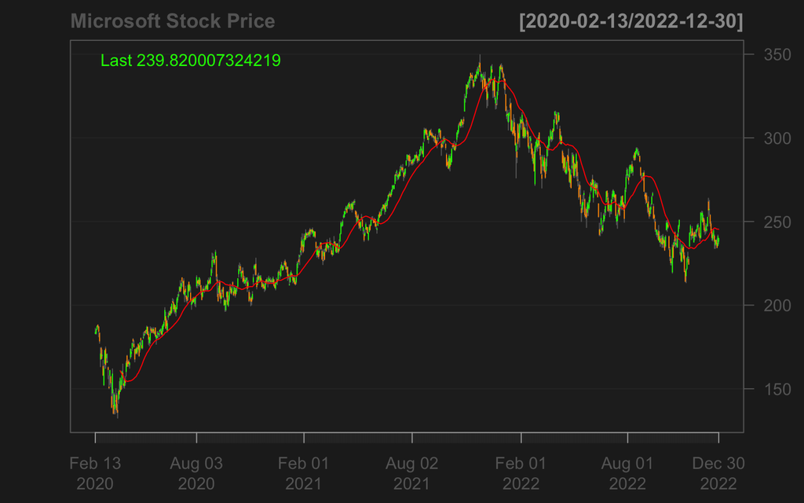

```r
# 微软
chartSeries(MSFT, name = "Microsoft Stock Price", TA = "addSMA(n = 30, col = 'red')")
```

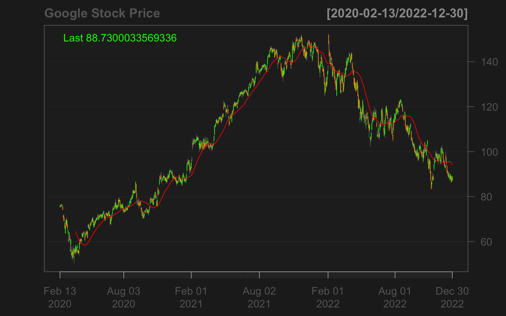

```r
# 谷歌
chartSeries(GOOG, name = "Google Stock Price", TA = "addSMA(n = 30, col = 'red')")
```

## 2. 自回归模型（AR，Autoregressive Model）

自回归模型是时间序列分析中的一种重要工具，用于预测和分析时间序列数据中的变量。下面，我将先给出定义和用途，然后通过一个R语言的示例来解释如何应用AR模型分析股票数据。

### 自回归模型（AR）定义

自回归模型是一种表达当前值与其历史值之间关系的模型。在这个模型中，当前时间点的值是过去若干时间点值的线性组合加上一个随机误差项。

### AR模型的组成

- **公式**:
  - $X_t = c + \phi_1 X_{t-1} + \phi_2 X_{t-2} + ... + \phi_p X_{t-p} + \epsilon_t$
  - 其中，$X_t$ 是当前值，$\phi$ 是模型参数，$\epsilon_t$ 是误差项。

### AR模型的用途

- 预测时间序列的未来值。
- 分析数据中的时间依赖性。
- 在金融和经济领域，用于分析和预测股票价格、经济指标等。

### R语言实例：股票数据分析

使用R语言中的`forecast`包来对股票数据应用AR模型。

**第一步：获取并准备股票数据**

```r
# 以苹果公司股票为例
getSymbols("AAPL", src = "yahoo", from = "2020-01-01", to = "2021-01-01")
```

```
## [1] "AAPL"
```

```r
apple_stock <- Cl(AAPL)  # 提取收盘价
```

**第二步：应用AR模型**

```r
# 应用AR模型
ar_model <- auto.arima(apple_stock, seasonal = FALSE)

# 查看模型细节
summary(ar_model)
```

```
## Series: apple_stock
## ARIMA(2,1,2)
##
## Coefficients:
##           ar1      ar2     ma1     ma2
##       -1.8516  -0.9749  1.8266  0.9335
## s.e.   0.0384   0.0395  0.0656  0.0746
##
## sigma^2 = 6.416:  log likelihood = -590.21
## AIC=1190.42   AICc=1190.67   BIC=1208.07
##
## Training set error measures:
##                     ME     RMSE     MAE       MPE     MAPE      MASE       ACF1
## Training set 0.2307033 2.507812 1.80745 0.1885303 1.948679 0.9678808 -0.0980967
```

根据自回归积分滑动平均（ARIMA）模型的结果，针对苹果公司股票的时间序列数据。这个模型用于预测未来的股价变动。让我们分析这些结果的每个部分：

### 模型类型

- **ARIMA(2,1,2)** 表示选用的是ARIMA模型，其中参数的含义是：
  - p（自回归项数）= 2
  - d（差分次数）= 1
  - q（移动平均项数）= 2

### 模型系数

- **ar1 (AR项1) 的系数** = -1.8516，标准误差 = 0.0384
- **ar2 (AR项2) 的系数** = -0.9749，标准误差 = 0.0395
- **ma1 (MA项1) 的系数** = 1.8266，标准误差 = 0.0656
- **ma2 (MA项2) 的系数** = 0.9335，标准误差 = 0.0746

这些系数表示模型中每个AR和MA项的权重。标准误差表示估计的不确定性。

### 模型评价指标

- **sigma^2** = 6.416：模型误差项的方差，较低的值通常表示较好的模型拟合。
- **对数似然值 (log likelihood)** = -590.21：越接近0通常表示模型拟合越好。
- **AIC (赤池信息准则)** = 1190.42：用于模型比较，值越小越好。
- **AICc** = 1190.67：对小样本数据进行校正的AIC。
- **BIC (贝叶斯信息准则)** = 1208.07：与AIC类似，但对复杂模型给予更大的惩罚。

### 训练集误差指标

- **ME (平均误差)** = 0.2307033：预测值和实际值之间的平均差异。
- **RMSE (均方根误差)** = 2.507812：衡量模型预测误差的平方根，越小越好。
- **MAE (平均绝对误差)** = 1.80745：预测误差的平均绝对值，越小越好。
- **MPE (平均百分比误差)** = 0.1885303：预测误差的百分比，用于衡量准确度。
- **MAPE (平均绝对百分比误差)** = 1.948679：平均绝对百分比误差，较低的值表示较好的预测准确度。
- **MASE (平均绝对标度误差)** = 0.9678808：相对于简单的基准模型的误差。
- **ACF1 (一阶自相关系数)** = -0.0980967：误差项的一阶自相关，接近0表示误差之间没有自相关。

### 结论

这个ARIMA模型提供了苹果公司股价时间序列的一个较为复杂的分析。模型的拟合度和预测准确性通过上述指标进行评估。从提供的数据来看，模型似乎能够合理地拟合历史数据，但任何基于此模型的预测都应该考虑到其固有的不确定性。在进行股价预测时，应谨慎使用，并考虑市场的多变性和外部因素的影响。

**第三步：进行预测**

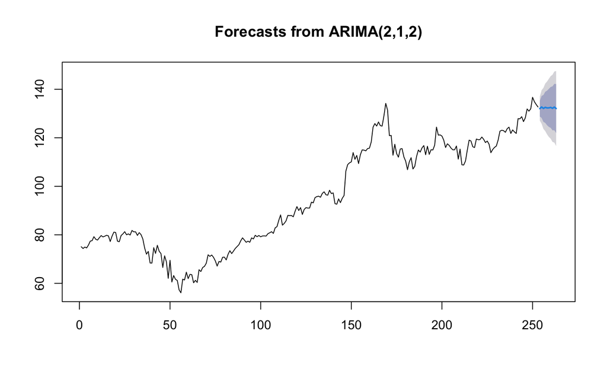

```r
# 对未来10个时间点进行预测
forecast_ar <- forecast(ar_model, h = 10)

# 绘制预测图
plot(forecast_ar)
```

## 3. 自回归移动平均模型（Autoregressive Moving Average, ARMA）

ARMA模型适合分析平稳的时间序列数据。它结合了自回归（AR）和移动平均（MA）两个部分。

- **公式**:
  - $X_t = c + \phi_1 X_{t-1} + ... + \phi_p X_{t-p} + \theta_1 \epsilon_{t-1} + ... + \theta_q \epsilon_{t-q} + \epsilon_t$
- **组成**:
  - AR（自回归）部分和MA（移动平均）部分。
- **应用**:
  - 在平稳序列上提供更精确的拟合。

### R语言实例：ARMA模型

```r
# 使用forecast包
library(forecast)

# 假设apple_stock是已经获取的苹果公司股价时间序列数据
# 首先确保数据是平稳的
# 使用auto.arima函数来自动选择合适的ARMA模型
arma_model <- auto.arima(apple_stock, seasonal = FALSE)

# 查看模型摘要
summary(arma_model)
```

```
## Series: apple_stock
## ARIMA(2,1,2)
##
## Coefficients:
##           ar1      ar2     ma1     ma2
##       -1.8516  -0.9749  1.8266  0.9335
## s.e.   0.0384   0.0395  0.0656  0.0746
##
## sigma^2 = 6.416:  log likelihood = -590.21
## AIC=1190.42   AICc=1190.67   BIC=1208.07
##
## Training set error measures:
##                     ME     RMSE     MAE       MPE     MAPE      MASE       ACF1
## Training set 0.2307033 2.507812 1.80745 0.1885303 1.948679 0.9678808 -0.0980967
```

## 4. 自回归积分滑动平均模型（Autoregressive Integrated Moving Average, ARIMA）

ARIMA模型是ARMA模型的扩展，适用于非平稳数据。它首先对数据进行差分处理以使其平稳，然后应用ARMA模型。

- **组成**:
  - AR（自回归）、I（差分）、MA（移动平均）。
- **应用**:
  - 广泛用于非平稳时间序列数据的预测。

```r
### R语言实例：ARIMA模型
# 继续使用forecast包
# ARIMA模型通常用于非平稳数据
arima_model <- auto.arima(apple_stock)

# 查看模型摘要
summary(arima_model)
```

```
## Series: apple_stock
## ARIMA(2,1,2)
##
## Coefficients:
##           ar1      ar2     ma1     ma2
##       -1.8516  -0.9749  1.8266  0.9335
## s.e.   0.0384   0.0395  0.0656  0.0746
##
## sigma^2 = 6.416:  log likelihood = -590.21
## AIC=1190.42   AICc=1190.67   BIC=1208.07
##
## Training set error measures:
##                     ME     RMSE     MAE       MPE     MAPE      MASE       ACF1
## Training set 0.2307033 2.507812 1.80745 0.1885303 1.948679 0.9678808 -0.0980967
```

## 5. 季节性自回归积分滑动平均模型（Seasonal Autoregressive Integrated Moving-Average, SARIMA）

SARIMA模型是ARIMA模型的扩展，用于具有明显季节性模式的数据。

- **特点**:
  - 额外的季节性元素来捕捉季节性模式。
- **应用**:
  - 预测季节性变化明显的时间序列数据。

### R语言实例：SARIMA模型

```r
# 假设apple_stock数据表现出季节性
# 使用auto.arima函数，指定季节性参数
sarima_model <- auto.arima(apple_stock, seasonal = TRUE)

# 查看模型摘要
summary(sarima_model)
```

```
## Series: apple_stock
## ARIMA(2,1,2)
##
## Coefficients:
##           ar1      ar2     ma1     ma2
##       -1.8516  -0.9749  1.8266  0.9335
## s.e.   0.0384   0.0395  0.0656  0.0746
##
## sigma^2 = 6.416:  log likelihood = -590.21
## AIC=1190.42   AICc=1190.67   BIC=1208.07
##
## Training set error measures:
##                     ME     RMSE     MAE       MPE     MAPE      MASE       ACF1
## Training set 0.2307033 2.507812 1.80745 0.1885303 1.948679 0.9678808 -0.0980967
```